# Predictive Modeling

October 31, 2016

## Overview

## Overview

- This presentation gives an overview of how different regression models can be applied to a dataset to predict an attribute
- We will be using the Credit dataset from "An Introduction to Statistical Learning" by James et all.

## Data

## Data

- `X`: row index
- `Income`: income (in thousands of dollars)
- `Limit`: credit limit
- `Rating`: credit rating
- `Cards`: number of credit cards
- `Age`: age
- `Education`: years of education
- `Gender`: gender
- `Student`: student status
- `Married`: marital status
- `Ethnicity`: Caucasian, African American or Asian
- `Balance`: average credit card debt

## Quantitative Data

First, some summary statistics about our data.

**Summary statistics quantitative variables**

|  | SD | Range |
| --- | --- | --- |
| Income | 35.244 | 176.280 |
| Limit | 2,308.199 | 13,058 |
| Rating | 154.724 | 889 |
| Cards | 1.371 | 8 |
| Age | 17.250 | 75 |
| Education | 3.125 | 15 |
| Balance | 459.759 | 1,999 |

- Large ranges for `Income` (in thousands), `Limit` and `Rating`
- `Balance` also has a large spread, with a range of \(1999\)

## Qualitative Data

Next, we look at the qualitative variables and their relative frequencies.

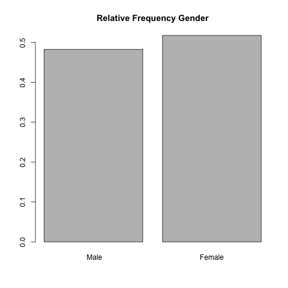

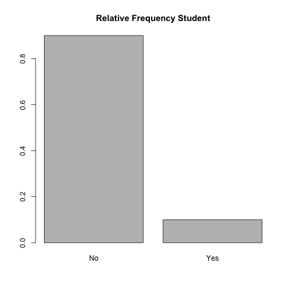

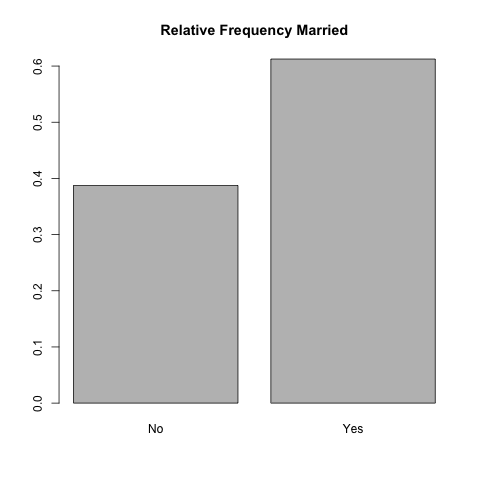

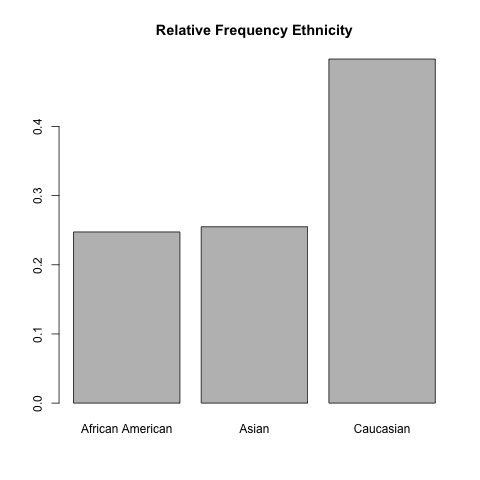

## Assocation between Balance and predictors

Visual representation of the correlation between `Balance` and each variable.

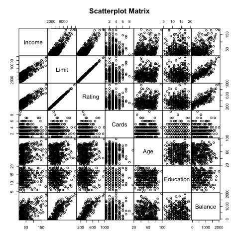

- Correlation between `Balance` and `Limit` and `Rating` appears to be linear

- Relationship between `Balance` and the other predictors less of a non-linear relationship

## Methodology

## Methods

*Ordinary Least Squares*: OLS is an approach to predicting a quantitative response \(Y\) based on a multiple predictor variables \(X_1\) through \(X_p\), where \(Y\) and \(X_1\) through \(X_p\) are vectors and each value in each \(X_{ij}\) (\(x_{ij}\)) has a corresponding value in \(Y\) (\(y_i\)).

*Shrinkage Methods*: Shrinkage is a general technique to improve a least-squares estimator which consists in reducing the variance by adding constraints on the value of coefficients.

- Ridge regression
- Lasso regression

## Methods (cont.)

*Dimension Reduction Methods*: dimension reduction is the process of reducing the number of random variables under consideration, via obtaining a set of principal variables.

- Principal Components regression (PCR)
- Partial Least Squares regression (PLSR)

## Analysis

## OSL

Our first method was OSL Regression. Below is the table of coefficients of each predictor when regressed against `Balance`

**Coefficient estimates OSL**

|  | Estimate | Std. Error | t value | Pr(> \| t\| ) |
| --- | --- | --- | --- | --- |
| (Intercept) | 0 | 0.042 | 0 | 1 |
| Income | 0.475 | 0.043 | 10.956 | 0 |
| Cards | 0.105 | 0.043 | 2.466 | 0.014 |
| Age | -0.080 | 0.044 | -1.835 | 0.067 |
| Education | -0.006 | 0.043 | -0.142 | 0.888 |
| GenderFemale | 0.016 | 0.043 | 0.376 | 0.707 |
| StudentYes | 0.250 | 0.043 | 5.824 | 0 |
| MarriedYes | -0.007 | 0.043 | -0.161 | 0.872 |
| EthnicityAsian | -0.014 | 0.053 | -0.262 | 0.794 |
| EthnicityCaucasian | 0.011 | 0.053 | 0.203 | 0.840 |

## Lasso

LASSO regression: fitting the model using out training data and cross-validating to determine the lambda value that minimizes mean-squared error.

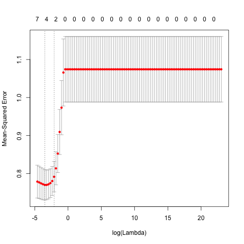

From this cross-validation, we found this minimum lambda value to be 0.0305386.

## Ridge Regression

We also ran a Ridge regression using the same methods as the LASSO regression. First we fit the model using out training data and cross-validated to determine the lambda value that minimizes mean-squared error: 0.1232847.

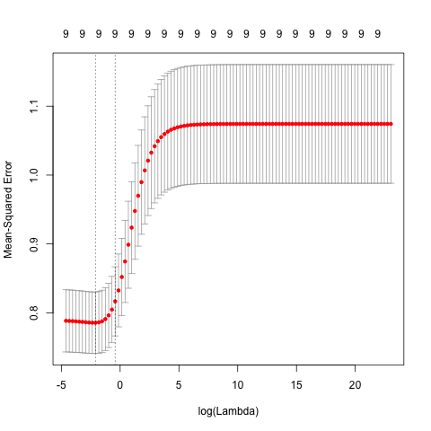

## Principle Component Analysis (PCA)

PCR fits the data the same way, but we now solve for the number of components with the smallest Predictive Residual Error Sum of Squares (\(PRESS\)).

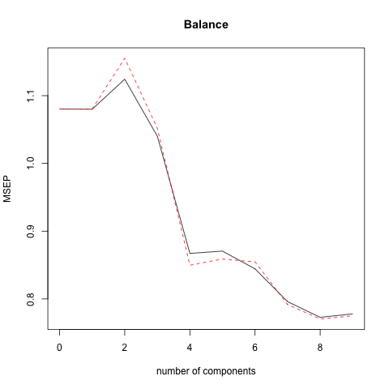

Fom our cross-validation, we find the number of components with the minimum \(PRESS\) value to be 8.

## PLSR

Like PLSR, we first fit the model using our training data and cross-validated to determine the number of components with the minimum \(PRESS\): 2.

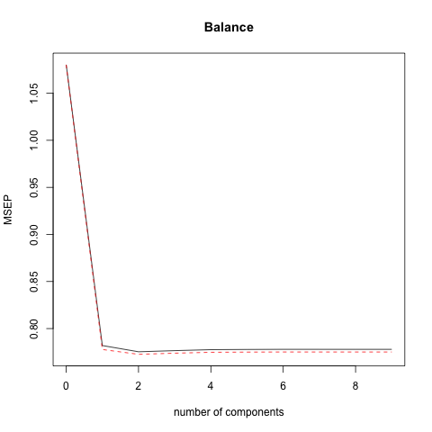

## Results

## Regression coefficients for all methods

[output not shown]

### Plotting the official coefficients

To get a better understanding of how to coefficient values differ across models, we plot the coefficient values for each model in the following overlapping line chart.

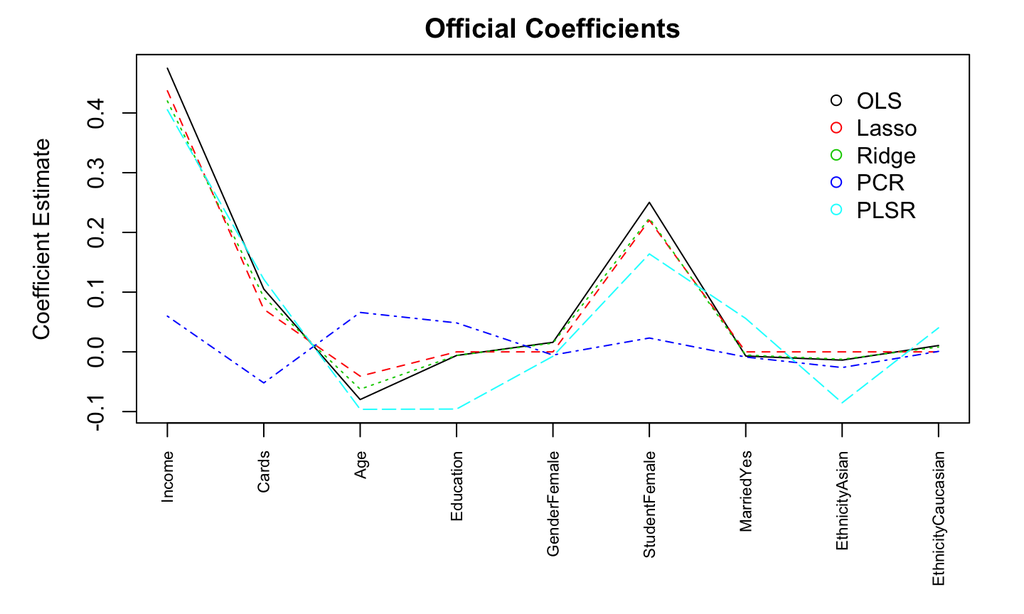

Coefficients of PCR are the most stable and most different than that of the other models. OSL, Ridge, LASSO, and PLSR all estimate similar coefficient values for each feature.

## MSE values for the regressions

To determine which model has the most predictive power of `Balance`, we compare the MSE of the various models.

|  | MSE Value |
| --- | --- |
| Lasso | 0.6472379 |
| Ridge | 0.6425785 |
| PCR | 1.1538700 |
| PLSR | 1.1544526 |

Because the Ridge coefficients fall in line with that of 3 other models (LASSO, PLSR, and OLS) and because it has the minimum MSE, we decide that of the models ran, Ridge has the best predictability of `Balance`.

## Conclusion

## Conclusion

And the winning model is… Ridge!

Of the models assessed in this analysis, we find that the Ridge model has the best predictive power of `Balance` because it has the lowest MSE of all the model and its estimated beta coefficients are consistant with the estimated coefficients of LASSO, OLS and PLSR